uq1

# Analyzing learner language using R

> Please copy this Jupyter notebook so that you are able to edit it.

> Simply go to: File > Save a copy in Drive

> Once you have done that, you are good to go.

This tutorial focuses on learner language and how to analyze differences between learners and L1 speakers of English using R. The entire R markdown document for this tutorial can be downloaded [here](https://slcladal.github.io/llr.Rmd).

The aim of this tutorial is to showcase how to extract information from essays from learners and L1 speakers of English and how to analyze these essays. The aim is not to provide a fully-fledged analysis but rather to show and exemplify some common methods for data extraction, processing, and analysis.

**Preparation and session set up**

This tutorial is based on R. If you have not installed R or are new to it, you will find an introduction to and more information how to use R [here](https://slcladal.github.io/intror.html). For this tutorials, we need to install certain *packages* from an R *library* so that the scripts shown below are executed without errors. Before turning to the code below, please install the packages by running the code below this paragraph. If you have already installed the packages mentioned below, then you can skip ahead and ignore this section. To install the necessary packages, simply run the following code - it may take some time (between 1 and 5 minutes to install all of the packages so you do not need to worry if it takes some time).

```r
# install packages
install.packages("quanteda")
install.packages("flextable")
install.packages("quanteda.textstats")
install.packages("quanteda.textplots")
install.packages("tidyverse")
install.packages("tm")
install.packages("tidytext")
install.packages("tidyr")
install.packages("NLP")
install.packages("openNLP")
install.packages("openNLPdata")
install.packages("koRpus")
install.packages("stringi")
install.packages("hunspell")
install.packages("wordcloud2")
install.packages("pacman")
# install the language support package
koRpus::install.koRpus.lang("en")
# install klippy for copy-to-clipboard button in code chunks
remotes::install_github("rlesur/klippy")
```

Now that we have installed the packages, we can activate them as shown below.

```r
# set options
options(stringsAsFactors = F)
options(scipen = 999)
options(max.print=1000)
options(java.parameters = c("-XX:+UseConcMarkSweepGC", "-Xmx8192m"))
#gc()
# load packages
library(tidyverse)
library(flextable)
library(tm)
library(tidytext)
library(tidyr)
library(NLP)
library(openNLP)
library(quanteda)
library(quanteda.textstats)
library(quanteda.textplots)
library(koRpus)
library(koRpus.lang.en)
library(stringi)
library(hunspell)
library(wordcloud2)
library(pacman)
pacman::p_load_gh("trinker/entity")
# activate klippy for copy-to-clipboard button
klippy::klippy()
```

Once you have installed R and RStudio and once you have also initiated the session by executing the code shown above, you are good to go.

**Loading data**

We use 7 essays written by learners from the [*International Corpus of Learner English* (ICLE)](https://uclouvain.be/en/research-institutes/ilc/cecl/icle.html) and two files containing a-level essays written by L1-English British students from [*The Louvain Corpus of Native English Essays* (LOCNESS)](https://uclouvain.be/en/research-institutes/ilc/cecl/locness.html) which was compiled by the *Centre for English Corpus Linguistics* (CECL), Université catholique de Louvain, Belgium. The code chunk below loads the data from the LADAL repository on GitHub into R.

```r
# load essays from l1 speakers
ns1 <- base::readRDS(url("https://slcladal.github.io/data/LCorpus/ns1.rda", "rb"))
ns2 <- base::readRDS(url("https://slcladal.github.io/data/LCorpus/ns2.rda", "rb"))
# load essays from l2 speakers
es <- base::readRDS(url("https://slcladal.github.io/data/LCorpus/es.rda", "rb"))
de <- base::readRDS(url("https://slcladal.github.io/data/LCorpus/de.rda", "rb"))
fr <- base::readRDS(url("https://slcladal.github.io/data/LCorpus/fr.rda", "rb"))
it <- base::readRDS(url("https://slcladal.github.io/data/LCorpus/it.rda", "rb"))
pl <- base::readRDS(url("https://slcladal.github.io/data/LCorpus/pl.rda", "rb"))
ru <- base::readRDS(url("https://slcladal.github.io/data/LCorpus/ru.rda", "rb"))
# inspect
ru %>%
  # remove header
  stringr::str_remove(., "<[A-Z]{4,4}.*") %>%
  # remove empty elements
  na_if("") %>%
  na.omit %>%
  #show first 3 elements
  head(3)
```

```
## [1] "It is now a very wide spread opinion, that in the modern world there is no place for dreaming and imagination. Those who share this point of view usually say that at present we are so very much under the domination of science, industry, technology, ever-increasing tempo of our lives and so o…
## [2] "As everything which is simple, the argument sounds very convincing. Of course, it is evident, that no modern writer, painter or musician can be compare to such names as Bach, Pushkin< Byron, Mozart, Rembrandt, Raffael et cetera. Modern pictures, in the majority of cases, seem to be merely re…
## [3] "But, I think, those, who put forward this argument, play - if I may put it like this - not fair game with their opponents, because such an approach presupposes the firm conviction, that dreaming and imagination can deal only with Arts, moreover, only with this \"well-established set\" of Art…
```

The data inspection shows the first 3 text elements from the essay written a Russian learner of English to provide an idea of what the data look like.

Now that we have loaded some data, we can go ahead and extract information from the texts and process the data to analyze differences between L1 speakers and learners of English.

# Concordancing

Concordancing refers to the extraction of words or phrases from a given text or texts (Lindquist 2009). Commonly, concordances are displayed in the form of key-word in contexts (KWIC) where the search term is shown with some preceding and following context. Thus, such displays are referred to as key word in context concordances. A more elaborate tutorial on how to perform concordancing with R is available [here](https://slcladal.github.io/kwics.html).

Concordancing is helpful for seeing how a given term or phrased is used in the data, for inspecting how often a given word occurs in a text or a collection of texts, for extracting examples, and it also represents a basic procedure, and often the first step, in more sophisticated analyses.

We begin by creating KWIC displays of the term *problem* as shown below. To extract the kwic concordances, we use the `kwic` function from the `quanteda` package (cf. Benoit et al. 2018).

```r
# combine data from l1 speakers
l1 <- c(ns1, ns2)
# combine data from learners
learner <- c(de, es, fr, it, pl, ru)
# extract kwic for term "problem" in learner data
kwic <- quanteda::kwic(learner,               # the data in which to search
                       pattern = "problem.*", # the pattern to look for
                       valuetype = "regex",   # look for exact matches or patterns
                       window = 10) %>%       # how much context to display (in elements)
  # convert to table (called data.frame in R)
  as.data.frame()
# inspect
head(kwic)
```

```
##   docname from  to                                                     pre
## 1  text12    8   8                      Many of the drug addits have legal
## 2  text12   31  31     countries , like Spain , illegal . They have social
## 3  text30   11  11     In our society there is a growing concern about the
## 4  text33  108 108 that once the availability of guns has been removed the
## 5  text33  139 139    honest way and remove any causes that could worsen a
## 6  text34   54  54       violence in our society . In order to analise the
##    keyword                                                       post   pattern
## 1 problems       because they steal money for buying the drug that is problem.*
## 2 problems         too because people are afraid of them and the drug problem.*
## 3  problem       of violent crime . In fact , particular attention is problem.*
## 4  problem of violence simply vanishes , but in this caotic situation problem.*
## 5  problem                    which is already particularly serious . problem.*
## 6  problem            in its complexity and allow people to live in a problem.*
```

We can also arrange the output according to what comes before or after the search term as shown below.

```r
# take kwic
kwic %>%
  # arrange kwic alphabetically by what comes after the key term
  dplyr::arrange(post)
```

```
##   docname from  to                                                          pre
## 1  text12    8   8                           Many of the drug addits have legal
## 2  text39  131 131 , greatest ideas were produced and solutions to many serious
## 3  text34   54  54            violence in our society . In order to analise the
## 4  text33  108 108      that once the availability of guns has been removed the
## 5  text30   11  11          In our society there is a growing concern about the
## 6  text12   31  31          countries , like Spain , illegal . They have social
## 7  text33  139 139         honest way and remove any causes that could worsen a
##    keyword                                                        post
## 1 problems        because they steal money for buying the drug that is
## 2 problems found . Most wonderful pieces of literature were created in
## 3  problem             in its complexity and allow people to live in a
## 4  problem  of violence simply vanishes , but in this caotic situation
## 5  problem        of violent crime . In fact , particular attention is
## 6 problems          too because people are afraid of them and the drug
## 7  problem                     which is already particularly serious .
##     pattern
## 1 problem.*
## 2 problem.*
## 3 problem.*
## 4 problem.*
## 5 problem.*
## 6 problem.*
## 7 problem.*
```

```r
# take quick
kwic %>%
  # reverse the preceding context
  dplyr::mutate(prerev = stringi::stri_reverse(pre)) %>%
  # arrange kwic alphabetically by reversed preceding context
  dplyr::arrange(prerev) %>%
  # remove column with reversed preceding context
  dplyr::select(-prerev)
```

```
##   docname from  to                                                          pre
## 1  text33  139 139         honest way and remove any causes that could worsen a
## 2  text33  108 108      that once the availability of guns has been removed the
## 3  text34   54  54            violence in our society . In order to analise the
## 4  text30   11  11          In our society there is a growing concern about the
## 5  text12    8   8                           Many of the drug addits have legal
## 6  text12   31  31          countries , like Spain , illegal . They have social
## 7  text39  131 131 , greatest ideas were produced and solutions to many serious
##    keyword                                                        post
## 1  problem                     which is already particularly serious .
## 2  problem  of violence simply vanishes , but in this caotic situation
## 3  problem             in its complexity and allow people to live in a
## 4  problem        of violent crime . In fact , particular attention is
## 5 problems        because they steal money for buying the drug that is
## 6 problems          too because people are afraid of them and the drug
## 7 problems found . Most wonderful pieces of literature were created in
##     pattern
## 1 problem.*
## 2 problem.*
## 3 problem.*
## 4 problem.*
## 5 problem.*
## 6 problem.*
## 7 problem.*
```

We can also combine concordancing with visualizations. For instance, use the `textplot_xray` function from the `quanteda.textplots` package to visualize where in some texts the term *people* and the term *imagination* occurs.

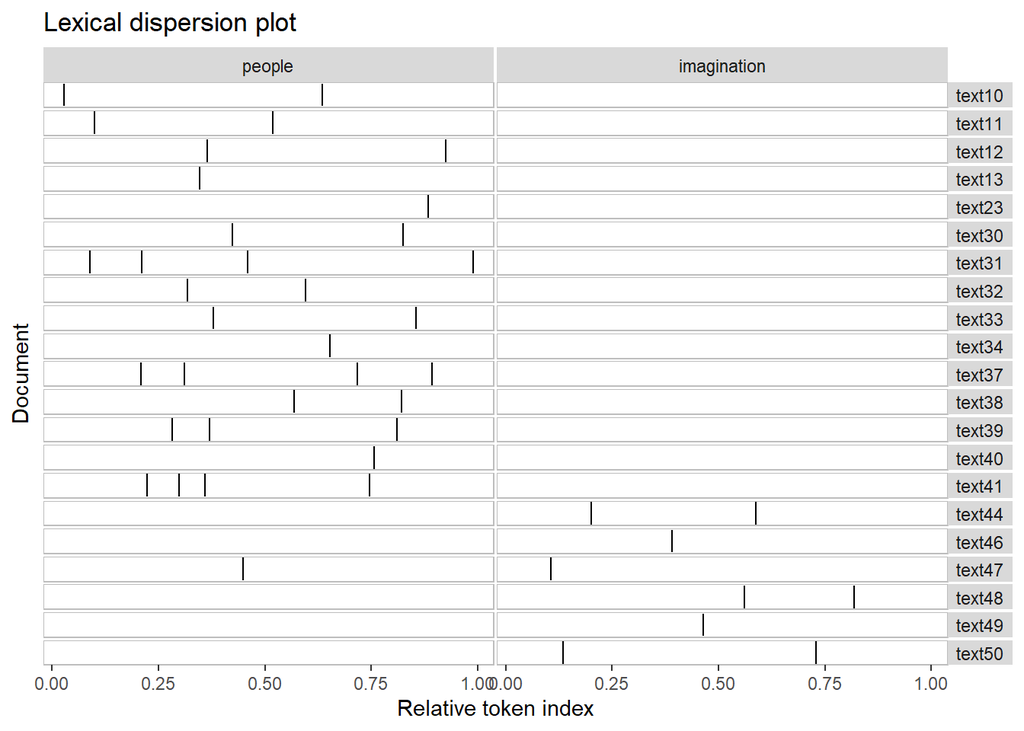

```r
# create kwics for people and imagination
kwic_people <- quanteda::kwic(learner, pattern = c("people", "imagination"))
# generate x-ray plot
quanteda.textplots::textplot_xray(kwic_people)
```

We can also search for phrases rather than individual words. To do this, we need to use the `phrase` function in the `pattern` argument as shown below. In the code chunk below, we look for any combination of the word *very* and any following word. It we would wish, we could of course also sort (or order) the concordances as we have done above.

```r
# generate kwic for phrases staring with very
kwic <- quanteda::kwic(learner,                              # data
                       pattern = phrase("^very [a-z]{1,}"),  # search pattern
                       valuetype = "regex") %>%              # type of pattern
  # convert into a data frame
  as.data.frame()
# inspect
head(kwic)
```

```
##   docname from  to                        pre          keyword
## 1   text3  193 194 in black trousers and only      very seldom
## 2   text4    9  10 is admirable is that she's      very active
## 3   text4   27  28        managed by her in a      very simple
## 4   text4   32  33    very simple way . She's  very interested
## 5   text5    3   4                 She's also very intelligent
## 6   text6    5   6          Last of all she's    very friendly
##                           post         pattern
## 1      in skirts , because she ^very [a-z]{1,}
## 2     in doing sports and that ^very [a-z]{1,}
## 3  way . She's very interested ^very [a-z]{1,}
## 4    in cycling , swimming and ^very [a-z]{1,}
## 5      and because of that she ^very [a-z]{1,}
## 6 and there's nearly nobody in ^very [a-z]{1,}
```

# Frequency lists

A useful procedure when dealing with texts is to extract frequency information. To exemplify how to extract frequency lists from texts, we will do this here using the L1 data.

```r
ftb <- c(ns1, ns2) %>%
  # remove punctuation
  stringr::str_replace_all(., "\\W", " ") %>%
  # remove superfluous white spaces
  stringr::str_squish() %>%
  # convert to lower case
  tolower() %>%
  # split into words
  stringr::str_split(" ") %>%
  # unlist
  unlist() %>%
  # convert into table
  as.data.frame() %>%
  # rename column
  dplyr::rename(word = 1) %>%
  # remove empty rows
  dplyr::filter(word != "") %>%
  # count words
  dplyr::group_by(word) %>%
  dplyr::summarise(freq = n()) %>%
  # order by freq
  dplyr::arrange(-freq)
# inspect
head(ftb)
```

```
## # A tibble: 6 x 2
##   word   freq
##   <chr> <int>
## 1 the     650
## 2 to      373
## 3 of      320
## 4 and     283
## 5 is      186
## 6 a       176
```

We can easily remove stop words (words without lexical content) using the `anti_join` function as shown below.

```r
ftb_wosw <- ftb %>%
  # remove stop words
  dplyr::anti_join(stop_words)
# inspect
head(ftb_wosw)
```

```
## # A tibble: 6 x 2
##   word       freq
##   <chr>     <int>
## 1 transport    98
## 2 people       85
## 3 roads        80
## 4 cars         69
## 5 road         51
## 6 system       50
```

We can then visualize the results as a bar chart as shown below.

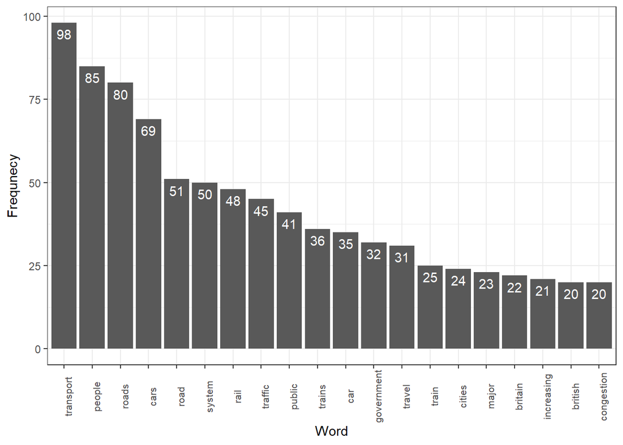

```r
ftb_wosw %>%
  # take 20 most frequent terms
  head(20) %>%
  # generate a plot
  ggplot(aes(x = reorder(word, -freq), y = freq, label = freq)) +
  # define type of plot
  geom_bar(stat = "identity") +
  # add labels
  geom_text(vjust=1.6, color = "white") +
  # display in black-and-whie theme
  theme_bw() +
  # adapt x-axis tick labels
  theme(axis.text.x = element_text(size=8, angle=90)) +
  # adapt axes labels
  labs(y = "Frequnecy", x = "Word")
```

Or we can visualize the data as a word cloud (see below).

```r
# create wordcloud
wordcloud2(ftb_wosw[1:100,],    # define data to use
           # define shape
           shape = "diamond",
           # define colors
           color = scales::viridis_pal()(8))
```

[interactive chart not shown]

# Splitting texts into sentences

It can be every useful to split texts into individual sentences. This can be done, e.g., to extract the average sentence length or simply to inspect or annotate individual sentences. To split a text into sentences, we clean the data by removing file identifiers and html tags as well as quotation marks within sentences. As we are dealing with several texts, we write a function that performs this task and that we can then apply to the individual texts.

```r
cleanText <- function(x,...){
  require(tokenizers)
  # paste text together
  x <- paste0(x)
  # remove file identifiers
  x <- stringr::str_remove_all(x, "<.*?>")
  # remove quotation marks
  x <- stringr::str_remove_all(x, fixed("\""))
  # remove empty elements
  x <- x[!x==""]
  # split text into sentences
  x <- tokenize_sentences(x)
  x <- unlist(x)
}
# clean texts
ns1_sen <- cleanText(ns1)
ns2_sen <- cleanText(ns2)
de_sen <- cleanText(de)
es_sen <- cleanText(es)
fr_sen <- cleanText(fr)
it_sen <- cleanText(it)
pl_sen <- cleanText(pl)
ru_sen <- cleanText(ru)
# inspect
head(ru_sen)
```

```
## [1] "It is now a very wide spread opinion, that in the modern world there is no place for dreaming and imagination."
## [2] "Those who share this point of view usually say that at present we are so very much under the domination of science, industry, technology, ever-increasing tempo of our lives and so on, that neither dreaming nor imagination can possibly survive."
## [3] "Their usual argument is very simple - they suggest to their opponents to look at some samples of the modern art and to compare them to the masterpieces of the Old Masters of painting, music, literature."
## [4] "As everything which is simple, the argument sounds very convincing."
## [5] "Of course, it is evident, that no modern writer, painter or musician can be compare to such names as Bach, Pushkin< Byron, Mozart, Rembrandt, Raffael et cetera."
## [6] "Modern pictures, in the majority of cases, seem to be merely repetitions or combinations of the images and methods of painting, invented very long before."
```

Now that we have split the texts into individual sentences, we can easily extract and visualize the average sentence lengths of L1 speakers and learners of English.

# Sentence length

The most basic complexity measure is average sentence length. In the following, we will extract the average sentence length for L1-speakers and learners of English with different language backgrounds.

We can use the `count_words` function from the `tokenizers` package to count the words in each sentence. We apply the function to all texts and generate a table (a data frame) of the results and add the L1 of the speaker who produced the sentence.

```r
# extract sentences lengths
ns1_sl <- tokenizers::count_words(ns1_sen)
ns2_sl <- tokenizers::count_words(ns2_sen)
de_sl <- tokenizers::count_words(de_sen)
es_sl <- tokenizers::count_words(es_sen)
fr_sl <- tokenizers::count_words(fr_sen)
it_sl <- tokenizers::count_words(it_sen)
pl_sl <- tokenizers::count_words(pl_sen)
ru_sl <- tokenizers::count_words(ru_sen)
# create a data frame from the results
sl_df <- data.frame(c(ns1_sl, ns2_sl, de_sl, es_sl, fr_sl, it_sl, pl_sl, ru_sl)) %>%
  dplyr::rename(sentenceLength = 1) %>%
  dplyr::mutate(l1 = c(rep("en", length(ns1_sl)),
                       rep("en", length(ns2_sl)),
                       rep("de", length(de_sl)),
                       rep("es", length(es_sl)),
                       rep("fr", length(fr_sl)),
                       rep("it", length(it_sl)),
                       rep("pl", length(pl_sl)),
                       rep("ru", length(ru_sl))))
# inspect
head(sl_df)
```

```
##   sentenceLength l1
## 1              2 en
## 2             17 en
## 3             23 en
## 4             17 en
## 5             20 en
## 6             34 en
```

Now, we can use the resulting table to create a box plot showing the results.

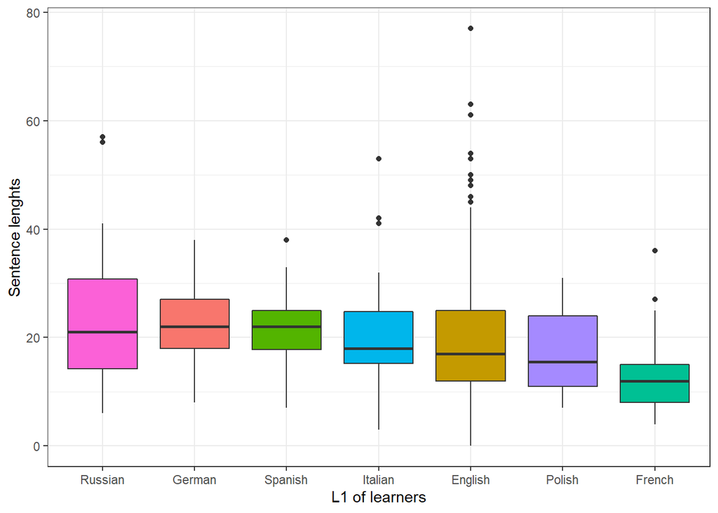

```r
sl_df %>%
  ggplot(aes(x = reorder(l1, -sentenceLength, mean), y = sentenceLength, fill = l1)) +
  geom_boxplot() +
  # adapt y-axis labels
  labs(y = "Sentence lenghts") +
  # adapt tick labels
  scale_x_discrete("L1 of learners",
                   breaks = names(table(sl_df$l1)),
                   labels = c("en" = "English",
                              "de" = "German",
                              "es" = "Spanish",
                              "fr" = "French",
                              "it" = "Italian",
                              "pl" = "Polish",
                              "ru" = "Russian")) +
  theme_bw() +
  theme(legend.position = "none")
```

# Extracting N-grams

In a next step, we extract n-grams using the `tokens_ngrams` function from the `quanteda` package. In a first step, we take the sentence data, convert it to lower case and remove punctuation. Then we apply the `tokens_ngrams` function to extract the n-grams (in this case 2-grams).

```r
ns1_tok <- ns1_sen %>%
  tolower() %>%
  quanteda::tokens(remove_punct = TRUE)
# extract n-grams
ns1_2gram <- quanteda::tokens_ngrams(ns1_tok, n = 2)
# inspect
head(ns1_2gram[[2]], 10)
```

```
##  [1] "the_basic"        "basic_dilema"     "dilema_facing"    "facing_the"
##  [5] "the_uk's"         "uk's_rail"        "rail_and"         "and_road"
##  [9] "road_transport"   "transport_system"
```

We can also extract tri-grams easily by changing the `n` argument in the `tokens_ngrams` function.

```r
# extract n-grams
ns1_3gram <- quanteda::tokens_ngrams(ns1_tok, n = 3)
# inspect
head(ns1_3gram[[2]])
```

```
## [1] "the_basic_dilema"    "basic_dilema_facing" "dilema_facing_the"
## [4] "facing_the_uk's"     "the_uk's_rail"       "uk's_rail_and"
```

We now apply the same procedure to all texts as shown below.

```r
ns1_tok <- ns1_sen %>% tolower() %>% quanteda::tokens(remove_punct = TRUE)
ns2_tok <- ns2_sen %>% tolower() %>% quanteda::tokens(remove_punct = TRUE)
de_tok <- de_sen %>% tolower() %>% quanteda::tokens(remove_punct = TRUE)
es_tok <- es_sen %>% tolower() %>% quanteda::tokens(remove_punct = TRUE)
fr_tok <- fr_sen %>% tolower() %>% quanteda::tokens(remove_punct = TRUE)
it_tok <- it_sen %>% tolower() %>% quanteda::tokens(remove_punct = TRUE)
pl_tok <- pl_sen %>% tolower() %>% quanteda::tokens(remove_punct = TRUE)
ru_tok <- ru_sen %>% tolower() %>% quanteda::tokens(remove_punct = TRUE)
# extract n-grams
ns1_2gram <- as.vector(unlist(quanteda::tokens_ngrams(ns1_tok, n = 2)))
ns2_2gram <- as.vector(unlist(quanteda::tokens_ngrams(ns2_tok, n = 2)))
de_2gram <- as.vector(unlist(quanteda::tokens_ngrams(de_tok, n = 2)))
es_2gram <- as.vector(unlist(quanteda::tokens_ngrams(es_tok, n = 2)))
fr_2gram <- as.vector(unlist(quanteda::tokens_ngrams(fr_tok, n = 2)))
it_2gram <- as.vector(unlist(quanteda::tokens_ngrams(it_tok, n = 2)))
pl_2gram <- as.vector(unlist(quanteda::tokens_ngrams(pl_tok, n = 2)))
ru_2gram <- as.vector(unlist(quanteda::tokens_ngrams(ru_tok, n = 2)))
```

Next, we generate a table with the ngrams and the L1 background of the speaker that produced the bi-grams.

```r
ngram_df <- c(ns1_2gram, ns2_2gram, de_2gram, es_2gram,
              fr_2gram, it_2gram, pl_2gram, ru_2gram) %>%
  as.data.frame() %>%
  dplyr::rename(ngram = 1) %>%
  dplyr::mutate(l1 = c(rep("en", length(ns1_2gram)),
                       rep("en", length(ns2_2gram)),
                       rep("de", length(de_2gram)),
                       rep("es", length(es_2gram)),
                       rep("fr", length(fr_2gram)),
                       rep("it", length(it_2gram)),
                       rep("pl", length(pl_2gram)),
                       rep("ru", length(ru_2gram))),
                learner = ifelse(l1 == "en", "no", "yes"))
# inspect
head(ngram_df)
```

```
##           ngram l1 learner
## 1  transport_01 en      no
## 2     the_basic en      no
## 3  basic_dilema en      no
## 4 dilema_facing en      no
## 5    facing_the en      no
## 6      the_uk's en      no
```

Now, we process the table further to add frequency information, i.e., how often a given n-gram occurs in each the language of speakers with distinct L1 backgrounds.

```r
ngram_fdf <- ngram_df %>%
  dplyr::group_by(ngram, learner) %>%
  dplyr::summarise(freq = n()) %>%
  dplyr::arrange(-freq)
# inspect
head(ngram_fdf)
```

```
## # A tibble: 6 x 3
## # Groups:   ngram [5]
##   ngram            learner  freq
##   <chr>            <chr>   <int>
## 1 of_the           no         72
## 2 to_the           no         40
## 3 in_the           no         39
## 4 public_transport no         35
## 5 of_the           yes        33
## 6 number_of        no         32
```

As the word counts of the texts are quite different, we normalize the frequencies to per-1,000-word frequencies which are comparable across texts of different lengths.

```r
ngram_nfdf <- ngram_fdf %>%
  dplyr::group_by(ngram) %>%
  dplyr::mutate(total_ngram = sum(freq)) %>%
  dplyr::arrange(-total_ngram) %>%
  # total by learner
  dplyr::group_by(learner) %>%
  dplyr::mutate(total_learner = sum(freq),
                rfreq = freq/total_learner*1000)
# inspect
head(ngram_nfdf, 10)
```

```
## # A tibble: 10 x 6
## # Groups:   learner [2]
##    ngram            learner  freq total_ngram total_learner rfreq
##    <chr>            <chr>   <int>       <int>         <int> <dbl>
##  1 of_the           no         72         105          9452  7.62
##  2 of_the           yes        33         105          3395  9.72
##  3 in_the           no         39          49          9452  4.13
##  4 in_the           yes        10          49          3395  2.95
##  5 to_the           no         40          47          9452  4.23
##  6 to_the           yes         7          47          3395  2.06
##  7 it_is            no         23          44          9452  2.43
##  8 it_is            yes        21          44          3395  6.19
##  9 public_transport no         35          35          9452  3.70
## 10 number_of        no         32          35          9452  3.39
```

We now reformat the table so that we have relative frequencies for both learners and L1 speakers even if a particular n-gram does not occur in the text produced by either a learner or a L1 speaker.

```r
ngram_rel <- ngram_nfdf %>%
  dplyr::select(ngram, learner, rfreq, total_ngram) %>%
  tidyr::spread(learner, rfreq) %>%
  dplyr::mutate(no = ifelse(is.na(no), 0, no),
                yes = ifelse(is.na(yes), 0, yes)) %>%
  tidyr::gather(learner, rfreq, no:yes) %>%
  dplyr::arrange(-total_ngram)
# inspect
head(ngram_rel)
```

```
## # A tibble: 6 x 4
##   ngram  total_ngram learner rfreq
##   <chr>        <int> <chr>   <dbl>
## 1 of_the         105 no       7.62
## 2 of_the         105 yes      9.72
## 3 in_the          49 no       4.13
## 4 in_the          49 yes      2.95
## 5 to_the          47 no       4.23
## 6 to_the          47 yes      2.06
```

Finally, we visualize the most frequent n-grams in the data in a bar chart.

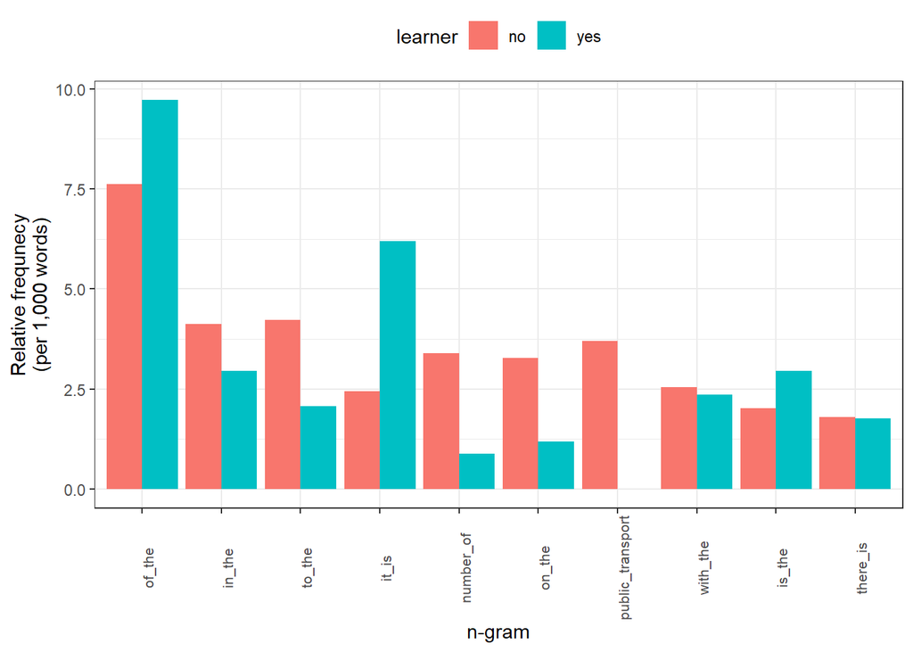

```r
ngram_rel %>%
  head(20) %>%
  ggplot(aes(y = rfreq, x = reorder(ngram, -total_ngram), group = learner, fill = learner)) +
  geom_bar(stat = "identity", position = position_dodge()) +
  theme_bw() +
  theme(axis.text.x = element_text(size=8, angle=90),
        legend.position = "top") +
  labs(y = "Relative frequnecy\n(per 1,000 words)", x = "n-gram")
```

We can, of course also investigate only specific n-grams, e.g., n-grams containing a specific word such as *public* (below, we only show the first 6 n-grams containing *public* by using the `head` function).

```r
ngram_rel %>%
  dplyr::filter(stringr::str_detect(ngram, "public")) %>%
  head()
```

```
## # A tibble: 6 x 4
##   ngram            total_ngram learner rfreq
##   <chr>                  <int> <chr>   <dbl>
## 1 public_transport          35 no      3.70
## 2 public_transport          35 yes     0
## 3 use_public                10 no      1.06
## 4 use_public                10 yes     0
## 5 of_public                  6 no      0.635
## 6 of_public                  6 yes     0
```

We can also specify the order by adding the underscore as shown below.

```r
ngram_rel %>%
  dplyr::filter(stringr::str_detect(ngram, "public_")) %>%
  head()
```

```
## # A tibble: 6 x 4
##   ngram             total_ngram learner rfreq
##   <chr>                   <int> <chr>   <dbl>
## 1 public_transport           35 no      3.70
## 2 public_transport           35 yes     0
## 3 public_action               1 no      0.106
## 4 public_and                  1 no      0.106
## 5 public_awareness            1 no      0.106
## 6 public_opposition           1 no      0.106
```

# Differences in ngram use

Next, we will set out to identify differences in n-gram frequencies between learners and L1 speakers. In a first step, we transform the table so that we have separate columns for learners and L1-speakers. In addition, we also add columns containing all the information we need to perform Fisher’s exact test to check if learners use certain n-grams significantly more or less frequently compared to L1-speakers.

```r
sdif_ngram <- ngram_fdf %>%
  tidyr::spread(learner, freq) %>%
  dplyr::mutate(no = ifelse(is.na(no), 0, no),
                yes = ifelse(is.na(yes), 0, yes)) %>%
  dplyr::rename(l1speaker = no,
                learner = yes) %>%
  dplyr::mutate(total_ngram = l1speaker+learner) %>%
  dplyr::ungroup() %>%
  dplyr::mutate(total_learner = sum(learner),
              total_l1 = sum(l1speaker)) %>%
  dplyr::mutate(a = l1speaker,
                b = learner) %>%
  dplyr::mutate(c = total_l1-a,
                d = total_learner-b)
# inspect
head(sdif_ngram)
```

```
## # A tibble: 6 x 10
##   ngram   l1speaker learner total_ngram total_learner total_l1     a     b     c
##   <chr>       <dbl>   <dbl>       <dbl>         <dbl>    <dbl> <dbl> <dbl> <dbl>
## 1 -to_cr~         1       0           1          3395     9452     1     0  9451
## 2 `_t             0       1           1          3395     9452     0     1  9452
## 3 £_1mil~         1       0           1          3395     9452     1     0  9451
## 4 £_bill~         1       0           1          3395     9452     1     0  9451
## 5 +_even          1       0           1          3395     9452     1     0  9451
## 6 +_peop~         1       0           1          3395     9452     1     0  9451
## # ... with 1 more variable: d <dbl>
```

On this re-arranged data set, we can now apply the Fisher’s exact tests. As we are performing many different tests, we need to correct for multiple comparisons. To this end, we create a column which holds the Bonferroni corrected critical value (.05). If a p-value is lower than the corrected critical value, then the learners and L1-speakers differ significantly in their use of that n-gram.

```r
sdif_ngram <- sdif_ngram  %>%
  # perform fishers exact test and extract estimate and p
  dplyr::rowwise() %>%
  dplyr::mutate(fisher_p = fisher.test(matrix(c(a,c,b,d), nrow= 2))$p.value,
                oddsratio = fisher.test(matrix(c(a,c,b,d), nrow= 2))$estimate,
                # calculate bonferroni correction
                crit = .05/nrow(.),
                sig_corr = ifelse(fisher_p < crit, "p<.05", "n.s.")) %>%
  dplyr::arrange(fisher_p) %>%
  dplyr::select(-total_ngram, -total_learner, -total_l1, -a, -b, -c, -d, -crit)
# inspect
head(sdif_ngram)
```

```
## # A tibble: 6 x 6
## # Rowwise:
##   ngram            l1speaker learner  fisher_p oddsratio sig_corr
##   <chr>                <dbl>   <dbl>     <dbl>     <dbl> <chr>
## 1 in_silence               0       8 0.0000236         0 n.s.
## 2 public_transport        35       0 0.0000276       Inf n.s.
## 3 silence_is               0       7 0.0000896         0 n.s.
## 4 of_all                   0       6 0.000339          0 n.s.
## 5 our_society              0       6 0.000339          0 n.s.
## 6 in_our                   0       5 0.00129           0 n.s.
```

In our case, there are no n-grams that differ significantly in their use by learners and L1-speakers once we have corrected for repeated testing as indicated by the *n.s.* (not significant) in the column called *sig_corr*.

# Finding collocations

There are various techniques for identifying collocations. To identify collocations without having a pre-defined target term, we can use the `textstat_collocations` function from the `quanteda.textstats` package (cf. Benoit et al. 2021).

However, before we can apply that function and start identifying collocations, we need to process the data to which we want to apply this function. In the present case, we will apply that function to the sentences in the L1 data which we extract in the code chunk below.

```r
ns_sen <- c(ns1_sen, ns2_sen) %>%
  tolower()
# inspect
head(ns_sen)
```

```
## [1] "transport 01"
## [2] "the basic dilema facing the uk's rail and road transport system is the general rise in population."
## [3] "this leads to an increase in the number of commuters and transport users every year, consequently putting pressure on the uks transports network."
## [4] "the biggest worry to the system is the rapid rise of car users outside the major cities."
## [5] "most large cities have managed to incourage commuters to use public transport thus decreasing major conjestion in rush hour periods."
## [6] "public transport is the obvious solution to to the increase in population if it is made cheep to commuters, clean, easy and efficient then it could take the strain of the overloaded british roads."
```

From the output shown above, we also see that splitting texts did not work perfectly as it produces some unwarranted artifacts like the “sentences” that consist of headings (e.g., *transport 01*). Fortunately, these errors do not really matter in the case of our example.

Now that we have the L1 data split into sentences, we can tokenize these sentences and apply the `textstat_collocations` function which identifies collocations.

```r
# create a token object
ns_tokens <- quanteda::tokens(ns_sen, remove_punct = TRUE)# %>%
#  tokens_remove(stopwords("english"))
# extract collocations
ns_coll <- quanteda.textstats::textstat_collocations(ns_tokens, size = 2, min_count = 20)
# inspect
head(ns_coll)
```

```
##        collocation count count_nested length   lambda        z
## 1 public transport    35            0      2 7.170227 14.89924
## 2            it is    23            0      2 3.119043 12.15265
## 3           of the    72            0      2 1.617862 11.45624
## 4           to use    21            0      2 3.458612 10.59222
## 5        number of    32            0      2 5.693830 10.06386
## 6           on the    31            0      2 2.103127  9.43355
```

The resulting table shows collocations in L1 data descending by collocation strength.

## Visualizing collocation networks

Network graphs are a very useful and flexible tool for visualizing relationships between elements such as words, personas, or authors. This section shows how to generate a network graph for collocations of the term *transport* using the `quanteda` package.

In a first step, we generate a document-feature matrix based on the sentences in the L1 data. A document-feature matrix shows how often elements (here these elements are the words that occur in the L1 data) occur in a selection of documents (here these documents are the sentences in the L1 data).

```r
# create document-feature matrix
ns_dfm <- ns_sen %>%
  #quanteda::dfm(remove_punct = TRUE) %>%
    quanteda::dfm(remove = stopwords('english'), remove_punct = TRUE)# %>%
    #quanteda::dfm_trim(min_termfreq = 10, verbose = FALSE)
# inspect
ns_dfm[1:6, 1:6]
```

```
## Document-feature matrix of: 6 documents, 6 features (72.22% sparse) and 0 docvars.
##        features
## docs    transport 01 basic dilema facing uk's
##   text1         1  1     0      0      0    0
##   text2         1  0     1      1      1    1
##   text3         1  0     0      0      0    0
##   text4         0  0     0      0      0    0
##   text5         1  0     0      0      0    0
##   text6         1  0     0      0      0    0
```

```r
# load function for co-occurrence calculation
source("https://slcladal.github.io/rscripts/calculateCoocStatistics.R")
# define term
coocTerm <- "transport"
# calculate co-occurrence statistics
coocs <- calculateCoocStatistics(coocTerm, ns_dfm, measure="LOGLIK")
# inspect results
coocs[1:10]
```

```
##     public        use    traffic       rail     facing  commuters    cheaper
## 113.171974  19.437311  10.508626   9.652830   9.382889   9.382889   9.382889
##      roads       less      buses
##   9.080648   8.067363   6.702863
```

```r
redux_dfm <- dfm_select(ns_dfm,
                        pattern = c(names(coocs)[1:10], "transport"))
# inspect
redux_dfm[1:6, 1:6]
```

```
## Document-feature matrix of: 6 documents, 6 features (63.89% sparse) and 0 docvars.
##        features
## docs    transport facing rail commuters use public
##   text1         1      0    0         0   0      0
##   text2         1      1    1         0   0      0
##   text3         1      0    0         1   0      0
##   text4         0      0    0         0   0      0
##   text5         1      0    0         1   1      1
##   text6         1      0    0         1   0      1
```

Now, we can transform the document-feature matrix into a feature-co-occurrence matrix as shown below. A feature-co-occurrence matrix shows how often each element in that matrix co-occurs with every other element in that matrix.

```r
tag_fcm <- fcm(redux_dfm)
# inspect
tag_fcm[1:6, 1:6]
```

```
## Feature co-occurrence matrix of: 6 by 6 features.
##            features
## features    transport facing rail commuters use public
##   transport         3      4   17         4  18     38
##   facing            0      0    2         0   0      0
##   rail              0      0    5         1   4      2
##   commuters         0      0    0         0   1      2
##   use               0      0    0         0   0     16
##   public            0      0    0         0   0      1
```

Using the feature-co-occurrence matrix, we can generate the network graph which shows the terms that collocate with the target term *transport* with the edges representing the co-occurrence frequency. To generate this network graph, we use the `textplot_network` function from the `quanteda.textplots` package.

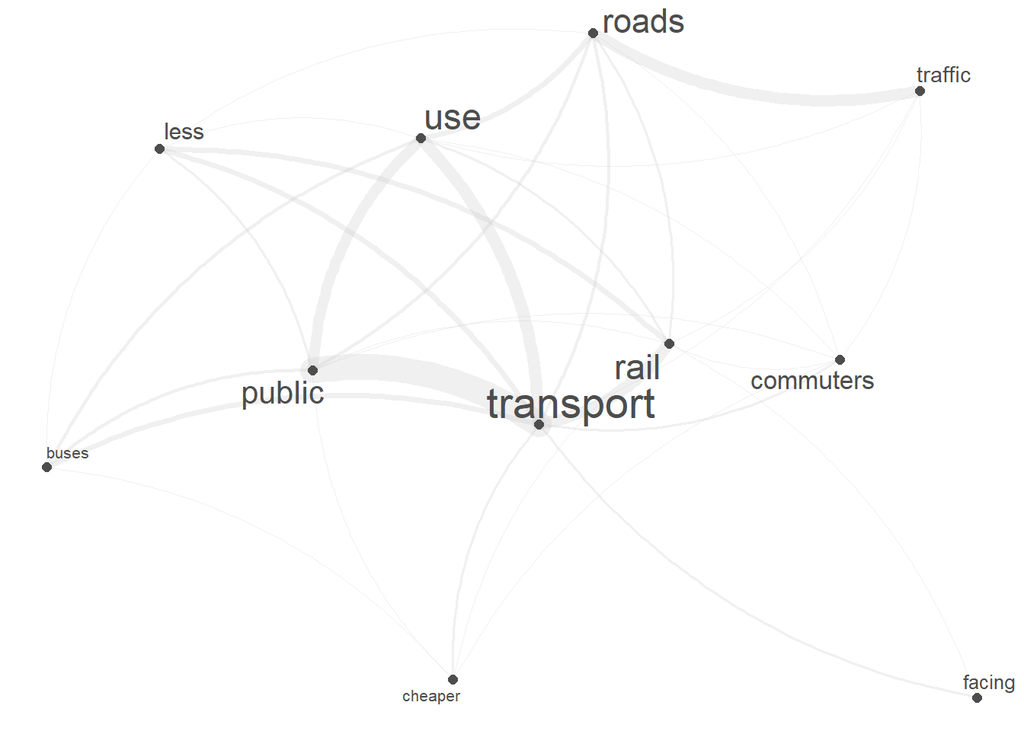

```r
# generate network graph
quanteda.textplots::textplot_network(tag_fcm,
                                     min_freq = 1,
                                     edge_alpha = 0.3,
                                     edge_size = 5,
                                     edge_color = "gray80",
                                     vertex_labelsize = log(rowSums(tag_fcm)*15))
```

# Part-of-speech tagging

Part-of-speech tagging is a very useful procedure for many analyses. Here, we automatically identify parts of speech (word classes) in the text which, for a well-studied language like English, is approximately 95% accurate.

The code chunk below defines a function which applies this kind of tagging to any text fed into the function.

```r
POStag <- function(x){
  # load necessary packages
  require("stringr")
  require("NLP")
  require("openNLP")
  # define annotators
  sent_token_annotator <- openNLP::Maxent_Sent_Token_Annotator()
  word_token_annotator <- openNLP::Maxent_Word_Token_Annotator()
  pos_tag_annotator <- openNLP::Maxent_POS_Tag_Annotator(language = "en", probs = FALSE)
  # convert all file content to strings
  strings <- lapply(x, function(x){
    x <- as.String(x)  })
  # loop over file contents
  sapply(strings, function(x){
    a <- NLP::annotate(x, list(sent_token_annotator, word_token_annotator))
    p <- NLP::annotate(x, pos_tag_annotator, a)
    w <- subset(p, type == "word")
    tags <- sapply(w$features, '[[', "POS")
    as <- sprintf("%s/%s", x[w], tags)
    at <- paste(as, collapse = " ")
    return(at)
    })
  }
```

We now apply this function to a test sentence to see if the function does what we want it to and to chck the output format.

```r
# generate test text
text <- "It is now a very wide spread opinion, that in the modern world there is no place for dreaming and imagination."
# apply pos-tag function to test text
tagged_text <- POStag(text)
# inspect result
tagged_text
```

```
## [1] "It/PRP is/VBZ now/RB a/DT very/RB wide/JJ spread/NN opinion/NN ,/, that/IN in/IN the/DT modern/JJ world/NN there/EX is/VBZ no/DT place/NN for/IN dreaming/VBG and/CC imagination/NN ./."
```

The tags which you see here are from the tag set developed for the *Penn Treebank*, a corpus of English text with syntactic annotations. The tags are not always transparent, and this is very much the case for the word class we will be looking at - the tag for an adjective is `/JJ`!

The next step, we write a function that will clean our texts by removing tags and quotation marks as well as superfluous white spaces.

```r
comText <- function(x,...){
  # paste text together
  x <- paste0(x)
  # remove file identifiers
  x <- stringr::str_remove_all(x, "<.*?>")
  # remove quotation marks
  x <- stringr::str_remove_all(x, fixed("\""))
  # remove superfluous white spaces
  x <- stringr::str_squish(x)
  # remove empty elements
  x <- x[!x==""]
}
```

Now we apply the text cleaning function to the texts.

```r
# combine texts
ns1_com <- comText(ns1_sen)
ns2_com <- comText(ns2_sen)
de_com <- comText(de_sen)
es_com <- comText(es_sen)
fr_com <- comText(fr_sen)
it_com <- comText(it_sen)
pl_com <- comText(pl_sen)
ru_com <- comText(ru_sen)
```

Now we apply the pos-tagging function to the texts.

```r
# apply pos-tag function to data
ns1_pos <- as.vector(unlist(POStag(ns1_com)))
ns2_pos <- as.vector(unlist(POStag(ns2_com)))
de_pos <- as.vector(unlist(POStag(de_com)))
es_pos <- as.vector(unlist(POStag(es_com)))
fr_pos <- as.vector(unlist(POStag(fr_com)))
it_pos <- as.vector(unlist(POStag(it_com)))
pl_pos <- as.vector(unlist(POStag(pl_com)))
ru_pos <- as.vector(unlist(POStag(ru_com)))
# inspect
head(ns1_pos)
```

```
## [1] "Transport/NNP 01/CD"
## [2] "The/DT basic/JJ dilema/NN facing/VBG the/DT UK/NNP 's/POS rail/NN and/CC road/NN transport/NN system/NN is/VBZ the/DT general/JJ rise/NN in/IN population/NN ./."
## [3] "This/DT leads/VBZ to/TO an/DT increase/NN in/IN the/DT number/NN of/IN commuters/NNS and/CC transport/NN users/NNS every/DT year/NN ,/, consequently/RB putting/VBG pressure/NN on/IN the/DT UKs/NNP transports/VBZ network/NN ./."
## [4] "The/DT biggest/JJS worry/NN to/TO the/DT system/NN is/VBZ the/DT rapid/JJ rise/NN of/IN car/NN users/NNS outside/IN the/DT major/JJ cities/NNS ./."
## [5] "Most/JJS large/JJ cities/NNS have/VBP managed/VBN to/TO incourage/VB commuters/NNS to/TO use/VB public/JJ transport/NN thus/RB decreasing/VBG major/JJ conjestion/NN in/IN Rush/NNP hour/NN periods/NNS ./."
## [6] "Public/NNP transport/NN is/VBZ the/DT obvious/JJ solution/NN to/TO to/TO the/DT increase/NN in/IN population/NN if/IN it/PRP is/VBZ made/VBN cheep/NN to/TO commuters/NNS ,/, clean/JJ ,/, easy/JJ and/CC efficient/JJ then/RB it/PRP could/MD take/VB the/DT strain/NN of/IN the/DT overloaded/VBN …
```

We end up with pos-tagged texts where the pos-tags are added to each word (or symbol).

In the following section, we will use these pos-tags to identify potential differences between learners and L1-speakers of English.

# Differences in pos-sequences

To analyze differences in part-of-speech sequences between L1-speakers and learners of English,, we write a function that extracts pos-tag bigrams from the tagged texts.

```r
# tokenize and extract pos tags
posngram <- function(x,...){
  x <- x %>%
  stringr::str_remove_all("\\w*/") %>%
  quanteda::tokens(remove_punct = TRUE)  %>%
    quanteda::tokens_ngrams(n = 2) %>%
    stringr::str_remove_all("-")
  return(x)
}
```

We now apply the function to the pos-tagged texts.

```r
# apply pos-tag function to data
ns1_posng <- as.vector(unlist(posngram(ns1_pos)))
ns2_posng <- as.vector(unlist(posngram(ns2_pos)))
de_posng <- as.vector(unlist(posngram(de_pos)))
es_posng <- as.vector(unlist(posngram(es_pos)))
fr_posng <- as.vector(unlist(posngram(fr_pos)))
it_posng <- as.vector(unlist(posngram(it_pos)))
pl_posng <- as.vector(unlist(posngram(pl_pos)))
ru_posng <- as.vector(unlist(posngram(ru_pos)))
# inspect
head(ns1_posng)
```

```
## [1] "NNP_CD" "DT_JJ"  "JJ_NN"  "NN_VBG" "VBG_DT" "DT_NNP"
```

In a next step, we tabulate the results and add a column telling us about the L1 background of the speakers who have produced the texts.

```r
posngram_df <- c(ns1_posng, ns2_posng, de_posng, es_posng, fr_posng,
                 it_posng, pl_posng, ru_posng) %>%
  as.data.frame() %>%
  # rename column
  dplyr::rename(ngram = 1) %>%
  # add l1
  dplyr::mutate(l1 = c(rep("en", length(ns1_posng)),
                       rep("en", length(ns2_posng)),
                       rep("de", length(de_posng)),
                       rep("es", length(es_posng)),
                       rep("fr", length(fr_posng)),
                       rep("it", length(it_posng)),
                       rep("pl", length(pl_posng)),
                       rep("ru", length(ru_posng))),
                # add learner column
                learner = ifelse(l1 == "en", "no", "yes")) %>%
  # extract frequencies of ngrams
  dplyr::group_by(ngram, learner) %>%
  dplyr::summarise(freq = n()) %>%
  dplyr::arrange(-freq)
# inspect
head(posngram_df)
```

```
## # A tibble: 6 x 3
## # Groups:   ngram [6]
##   ngram learner  freq
##   <chr> <chr>   <int>
## 1 DT_NN no        495
## 2 IN_DT no        418
## 3 NN_IN no        417
## 4 JJ_NN no        314
## 5 DT_JJ no        243
## 6 TO_VB no        237
```

Next, we transform the table and add all the information that we need to perform the Fisher’s exact tests that we will use to determine if there are significant differences between L1 speakers and learners of English regarding their use of pos-sequences.

```r
posngram_df2 <- posngram_df %>%
  tidyr::spread(learner, freq) %>%
  dplyr::mutate(no = ifelse(is.na(no), 0, no),
                yes = ifelse(is.na(yes), 0, yes)) %>%
  dplyr::rename(l1speaker = no,
                learner = yes) %>%
  dplyr::mutate(total_ngram = l1speaker+learner) %>%
  dplyr::ungroup() %>%
  dplyr::mutate(total_learner = sum(learner),
              total_l1 = sum(l1speaker)) %>%
  dplyr::mutate(a = l1speaker,
                b = learner) %>%
  dplyr::mutate(c = total_l1-a,
                d = total_learner-b)
# inspect
head(posngram_df2)
```

```
## # A tibble: 6 x 10
##   ngram   l1speaker learner total_ngram total_learner total_l1     a     b     c
##   <chr>       <dbl>   <dbl>       <dbl>         <dbl>    <dbl> <dbl> <dbl> <dbl>
## 1 $_CC            0       1           1          3518     9621     0     1  9621
## 2 $_girl~         0       1           1          3518     9621     0     1  9621
## 3 $_IN            0       1           1          3518     9621     0     1  9621
## 4 $_JJ           14       4          18          3518     9621    14     4  9607
## 5 $_JJR           1       0           1          3518     9621     1     0  9620
## 6 $_NN           32      40          72          3518     9621    32    40  9589
## # ... with 1 more variable: d <dbl>
```

On this re-arranged data set, we can now apply the Fisher’s exact tests. As we are performing many different tests, we need to correct for multiple comparisons. To this end, we create a column which holds the Bonferroni corrected critical value (.05). If a p-value is lower than the corrected critical value, then the learners and L1-speakers differ significantly in their use of that n-gram.

```r
sdif_posngram <- posngram_df2  %>%
  # perform fishers exact test and extract estimate and p
  dplyr::rowwise() %>%
  dplyr::mutate(fisher_p = fisher.test(matrix(c(a,c,b,d), nrow= 2))$p.value,
                oddsratio = fisher.test(matrix(c(a,c,b,d), nrow= 2))$estimate,
                # calculate bonferroni correction
                crit = .05/nrow(.),
                sig_corr = ifelse(fisher_p < crit, "p<.05", "n.s.")) %>%
  dplyr::arrange(fisher_p) %>%
  dplyr::select(-total_ngram, -a, -b, -c, -d, -crit)
# inspect
head(sdif_posngram)
```

```
## # A tibble: 6 x 8
## # Rowwise:
##   ngram   l1speaker learner total_learner total_l1   fisher_p oddsratio sig_corr
##   <chr>       <dbl>   <dbl>         <dbl>    <dbl>      <dbl>     <dbl> <chr>
## 1 PRP_VBZ        43      55          3518     9621    1.13e-9     0.283 p<.05
## 2 NN_NNS        121      10          3518     9621    4.43e-8     4.47  p<.05
## 3 $_NN           32      40          3518     9621    2.82e-7     0.290 p<.05
## 4 IN_PRP         93      72          3518     9621    3.15e-6     0.467 p<.05
## 5 PRP_$          81      61          3518     9621    3.38e-5     0.481 p<.05
## 6 JJR_NNS        39       1          3518     9621    9.89e-5    14.3   n.s.
```

We can now check and compare the use of the the pos-tagged sequences that differ significantly between learners and L1 speakers of English using simple concordancing. We begin by checking the use in the L1-data.

```r
# combine l1 data
l1_pos <- c(ns1_pos, ns2_pos)
# combine l2 data
l2_pos <- c(de_pos, es_pos, fr_pos, it_pos, pl_pos, ru_pos)
# extract PRP_VBZ
PRP_VBZ_l1 <-quanteda::kwic(quanteda::tokens(l1_pos),
                            pattern = phrase("\\w* / PRP \\w* / VBZ"),
                            valuetype = "regex",
                            window = 10) %>%
  as.data.frame() %>%
  # remove superfluous columns
  dplyr::select(-from, -to, -docname, -pattern)
# inspect results
head(PRP_VBZ_l1)
```

```
##                                      pre                keyword
## 1     NN in / IN population / NN if / IN      it / PRP is / VBZ
## 2  DT concrete / JJ jungle / NN yet / CC      it / PRP is / VBZ
## 3 NN centres / NNS during / IN rush / NN ours / PRP comes / VBZ
## 4                                        It / PRP removes / VBZ
## 5                                            It / PRP has / VBZ
## 6                                            It / PRP has / VBZ
##                                         post
## 1    made / VBN cheep / NN to / TO commuters
## 2        only / RB trying / VBG to / TO cope
## 3        to / TO a / DT near / JJ standstill
## 4 the / DT element / NN of / IN independence
## 5      given / VBN us / PRP the / DT freedom
## 6    reached / VBN the / DT stage / NN where
```

We now turn to the learner data and also extract condordances for the same pos-sequence.

```r
# extract PRP_VBZ
PRP_VBZ_l2 <-quanteda::kwic(quanteda::tokens(l2_pos),
                            pattern = phrase("\\w* / PRP \\w* / VBZ"),
                            valuetype = "regex",
                            window = 10) %>%
  as.data.frame() %>%
  # remove superfluous columns
  dplyr::select(-from, -to, -docname, -pattern)
# inspect results
head(PRP_VBZ_l2)
```

```
##                                       pre               keyword
## 1       NN why / WRB I / PRP admire / VBP    her / PRP is / VBZ
## 2        WRB you / PRP look / VBP at / IN    her / PRP is / VBZ
## 3                                           She / PRP has / VBZ
## 4 $ shoulders / NNS and / CC usually / RB she / PRP wears / VBZ
## 5                                            She / PRP is / VBZ
## 6      IN skirts / NNS , / , because / IN she / PRP hates / VBZ
##                                         post
## 1              her / PRP $ beauty / NN . / .
## 2           really / RB brilliant / JJ . / .
## 3 glistening / VBG dark / JJ brown / JJ hair
## 4             a / DT hair / NN slide / NN or
## 5      always / RB well / RB dressed / VBN ,
## 6 wearing / VBG skirts / NNS and / CC tights
```

# Lexical diversity

Another common measure used to asses the development of language learns is vocabulary size. Vocabulary size can be assessed with various measures that represent lexical diversity. In the present case, we will extract

- `TTR`: *type-token ratio*
- `C`: Herdan’s C (cf. Tweedie and Baayen 1998; sometimes referred to as LogTTR)
- `R`: Guiraud’s Root TTR (cf. Tweedie and Baayen 1998)
- `CTTR`: Carroll’s Corrected TTR
- `U`: Dugast’s Uber Index (cf. Tweedie and Baayen 1998)
- `S`: Summer’s index
- `Maas`: Maas’ indices

The formulas showing how the lexical diversity measures are calculated as well as additional information about the lexical diversity measures can be found [here](https://quanteda.io/reference/textstat_lexdiv.html).

While we will extract all of these scores, we will only visualize Carroll’s Corrected TTR to keep things simple.

$$\begin{equation}
CTTR = \frac{N_{Types}}{\sqrt{2 N_{Tokens}}}
\end{equation}$$

However, before we extract the lexical diversity measures, we split the data into individual essays.

```r
cleanEss <- function(x){
  x %>%
  paste0(collapse = " ") %>%
  stringr::str_split("Transport [0-9]{1,2}") %>%
  unlist() %>%
  stringr::str_squish() %>%
  .[. != ""]
}
# apply function
ns1_ess <- cleanEss(ns1)
ns2_ess <- cleanEss(ns2)
de_ess <- cleanEss(de)
es_ess <- cleanEss(es)
fr_ess <- cleanEss(fr)
it_ess <- cleanEss(it)
pl_ess <- cleanEss(pl)
ru_ess <- cleanEss(ru)
# inspect
head(ns1_ess, 1)
```

```
## [1] "The basic dilema facing the UK's rail and road transport system is the general rise in population. This leads to an increase in the number of commuters and transport users every year, consequently putting pressure on the UKs transports network. The biggest worry to the system is the rapid ri…
```

In a next step, we can apply the `lex.div` function from the `koRpus` package which calculates the different lexical diversity measures for us.

```r
# extract lex. div. measures
ns1_lds <- lapply(ns1_ess, function(x){
  x <- koRpus::lex.div(x, force.lang = 'en', # define language
                       segment = 20,      # define segment width
                       window = 20,       # define window width
                       quiet = T,
                       # define lex div measures
                       measure=c("TTR", "C", "R", "CTTR", "U", "Maas"),
                       char=c("TTR", "C", "R", "CTTR","U", "Maas"))
})
# inspect
ns1_lds[1]
```

```
## [[1]]
##
## Total number of tokens: 217
## Total number of types:  134
##
## Type-Token Ratio
##                TTR: 0.62
##
## TTR characteristics:
##    Min. 1st Qu.  Median    Mean 3rd Qu.    Max.
##  0.6140  0.6322  0.6429  0.6888  0.7129  0.9000
##    SD
##  0.0852
##
##
## Herdan's C
##                  C: 0.91
##
## C characteristics:
##    Min. 1st Qu.  Median    Mean 3rd Qu.    Max.
##  0.8614  0.9059  0.9131  0.9157  0.9164  0.9648
##    SD
##  0.0186
##
##
## Guiraud's R
##                  R: 9.1
##
## R characteristics:
##    Min. 1st Qu.  Median    Mean 3rd Qu.    Max.
##   1.789   5.459   6.484   6.596   8.158   9.080
##    SD
##  1.8316
##
##
## Carroll's CTTR
##               CTTR: 6.43
##
## CTTR characteristics:
##    Min. 1st Qu.  Median    Mean 3rd Qu.    Max.
```

[output cut: 23 more lines]

```
##                 V': 0 (0 new types every 100 tokens)
##
## Maas Indices characteristics:
##    Min. 1st Qu.  Median    Mean 3rd Qu.    Max.
##  0.1644  0.1953  0.2104  0.2112  0.2177  0.4454
##    SD
##  0.0392
##    Min. 1st Qu.  Median    Mean 3rd Qu.    Max.
##   1.185   4.106   4.506   4.428   4.955   5.223
##    SD
##  0.7145
##    Min. 1st Qu.  Median    Mean 3rd Qu.    Max.
##   2.729   9.455  10.376  10.196  11.410  12.026
##    SD
##  1.6452
```

We now go ahead and extract the lexical diversity scores for the other essays.

```r
lexDiv <- function(x){
  lapply(x, function(y){
    koRpus::lex.div(y, force.lang = 'en',  segment = 20, window = 20,
                    quiet = T, measure=c("TTR", "C", "R", "CTTR", "U", "Maas"),
                    char=c("TTR", "C", "R", "CTTR","U", "Maas"))
  })
}

# extract lex. div. measures
ns2_lds <- lexDiv(ns2_ess)
de_lds <- lexDiv(de_ess)
es_lds <- lexDiv(es_ess)
fr_lds <- lexDiv(fr_ess)
it_lds <- lexDiv(it_ess)
pl_lds <- lexDiv(pl_ess)
ru_lds <- lexDiv(ru_ess)
```

In a next step, we extract the CTTR values from L1-speakers and learners and put the results into a table.

```r
cttr <- data.frame(c(as.vector(sapply(ns1_lds, '[', "CTTR")),
                     as.vector(sapply(ns2_lds, '[', "CTTR")),
                     as.vector(sapply(de_lds, '[', "CTTR")),
                     as.vector(sapply(es_lds, '[', "CTTR")),
                     as.vector(sapply(fr_lds, '[', "CTTR")),
                     as.vector(sapply(it_lds, '[', "CTTR")),
                     as.vector(sapply(pl_lds, '[', "CTTR")),
                     as.vector(sapply(ru_lds, '[', "CTTR"))),
          c(rep("en", length(as.vector(sapply(ns1_lds, '[', "CTTR")))),
            rep("en", length(as.vector(sapply(ns2_lds, '[', "CTTR")))),
            rep("de", length(as.vector(sapply(de_lds, '[', "CTTR")))),
            rep("es", length(as.vector(sapply(es_lds, '[', "CTTR")))),
            rep("fr", length(as.vector(sapply(fr_lds, '[', "CTTR")))),
            rep("it", length(as.vector(sapply(it_lds, '[', "CTTR")))),
            rep("pl", length(as.vector(sapply(pl_lds, '[', "CTTR")))),
            rep("ru", length(as.vector(sapply(ru_lds, '[', "CTTR")))))) %>%
  dplyr::rename(CTTR = 1,
                l1 = 2)
# inspect
head(cttr)
```

```
##   CTTR l1
## 1 6.43 en
## 2 8.84 en
## 3 8.20 en
## 4 8.34 en
## 5 7.34 en
## 6 8.78 en
```

We can now visualize the information in the table in the form of a dot plot to inspect potential differences with respect to the L1-background of speakers.

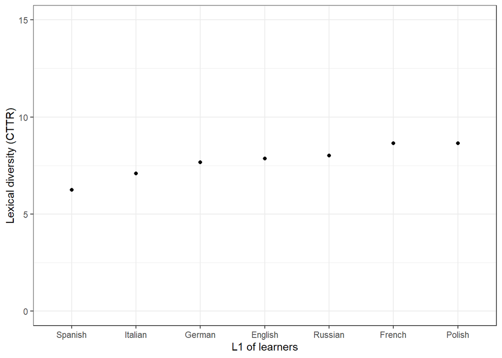

```r
cttr %>%
  dplyr::group_by(l1) %>%
  dplyr::summarise(CTTR = mean(CTTR)) %>%
  ggplot(aes(x = reorder(l1, CTTR, mean), y = CTTR)) +
  geom_point() +
  # adapt y-axis labels
  labs(y = "Lexical diversity (CTTR)") +
  # adapt tick labels
  scale_x_discrete("L1 of learners",
                   breaks = names(table(cttr$l1)),
                   labels = c("en" = "English",
                              "de" = "German",
                              "es" = "Spanish",
                              "fr" = "French",
                              "it" = "Italian",
                              "pl" = "Polish",
                              "ru" = "Russian")) +
  theme_bw() +
  coord_cartesian(ylim = c(0, 15)) +
  theme(legend.position = "none")
```

# Readability

Another measure to assess text quality or text complexity is *readability*. As with lexical diversity scores, the `textstat_readability` function from the `quanteda.textstats` package provides a multitude of different measures (see [here](https://quanteda.io/reference/textstat_readability.html) for the entire list of readability scores that can be extracted). In the following, we will focus on Flesch’s Reading Ease Score exclusively (cf. Flesch 1948) (see below; ALS = average sentence length).

$$\begin{equation}
Flesch = 206.835−(1.015 ASL)−(84.6 \frac{N_{Syllables}}{N_{Words}})
\end{equation}$$

In a first step, we extract the Flesch scores by applying the `textstat_readability` to the essays.

```r
ns1_read <- quanteda.textstats::textstat_readability(ns1_ess)
ns2_read <- quanteda.textstats::textstat_readability(ns2_ess)
de_read <- quanteda.textstats::textstat_readability(de_ess)
es_read <- quanteda.textstats::textstat_readability(es_ess)
fr_read <- quanteda.textstats::textstat_readability(fr_ess)
it_read <- quanteda.textstats::textstat_readability(it_ess)
pl_read <- quanteda.textstats::textstat_readability(pl_ess)
ru_read <- quanteda.textstats::textstat_readability(ru_ess)
# inspect
ns1_read
```

```
##    document   Flesch
## 1     text1 43.12767
## 2     text2 62.34563
## 3     text3 63.16179
## 4     text4 62.90455
## 5     text5 53.53250
## 6     text6 56.92020
## 7     text7 53.89138
## 8     text8 59.28742
## 9     text9 62.26228
## 10   text10 53.60807
## 11   text11 58.24022
## 12   text12 58.36792
## 13   text13 55.85388
## 14   text14 48.55222
## 15   text15 55.41899
## 16   text16 62.98538
```

Now, we generate a table with the results and the L1 of the speaker that prodced the essay.

```r
read <- rbind(ns1_read, ns2_read, de_read, es_read, fr_read, it_read, pl_read, ru_read) %>%
  dplyr::mutate(l1 = c(rep("en", nrow(ns1_read)),
                       rep("en", nrow(ns2_read)),
                       rep("de", nrow(de_read)),
                       rep("es", nrow(es_read)),
                       rep("fr", nrow(fr_read)),
                       rep("it", nrow(it_read)),
                       rep("pl", nrow(pl_read)),
                       rep("ru", nrow(ru_read)))) %>%
  dplyr::group_by(l1) %>%
  dplyr::summarise(Flesch = mean(Flesch))
# inspect
head(read)
```

```
## # A tibble: 6 x 2
##   l1    Flesch
##   <chr>  <dbl>
## 1 de      65.2
## 2 en      56.7
## 3 es      57.6
## 4 fr      66.4
## 5 it      55.4
## 6 pl      62.5
```

As before, we can visualize the results to check for potential differences between L1-speakers and learners of English. In this case, we use bar charts to visualize the results.

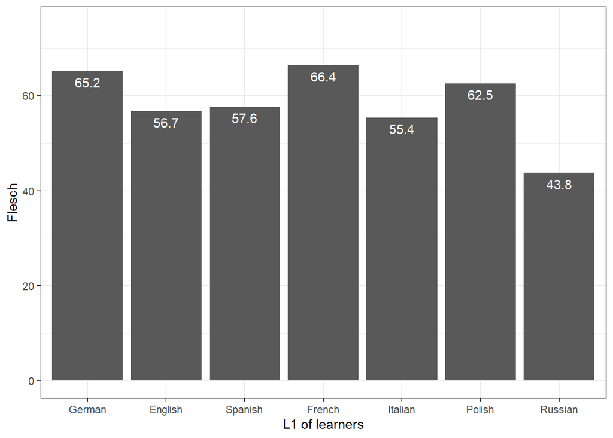

```r
read %>%
  ggplot(aes(x = l1, y = Flesch, label = round(Flesch, 1))) +
  geom_bar(stat = "identity") +
  geom_text(vjust=1.6, color = "white")+
  # adapt tick labels
  scale_x_discrete("L1 of learners",
                   breaks = names(table(read$l1)),
                   labels = c("en" = "English",
                              "de" = "German",
                              "es" = "Spanish",
                              "fr" = "French",
                              "it" = "Italian",
                              "pl" = "Polish",
                              "ru" = "Russian")) +
  theme_bw() +
  coord_cartesian(ylim = c(0, 75)) +
  theme(legend.position = "none")
```

# Spelling errors

We can also determine the number of spelling errors in L1 and learner texts by checking if words in a given text occur in a dictionary or not. To do this, we can use the `hunspell` function from the `hunspell` package. We can choose between different dictionaries (use `list_dictionaries()` to see which dictionaries are available) and we can specify words to ignore via the `ignore` argument.

```r
# list words that are not in dict
hunspell(ns1_ess,
         format = c("text"),
         dict = dictionary("en_GB"),
         ignore = en_stats)
```

```
## [[1]]
## [1] "dilema"     "UKs"        "incourage"  "conjestion" "Tourturing"
##
## [[2]]
## [1] "appealling"
##
## [[3]]
## [1] "dependance" "recieve"    "travell"
##
## [[4]]
## [1] "ie"          "Improvent"   "maintanence" "theier"      "airplanes"
## [6] "buisness"    "thier"       "ie"          "etc"
##
## [[5]]
## [1] "tendancy"     "etc"          "HGV's"        "Eurotunnel"   "Eurotunnel's"
##
## [[6]]
## [1] "indaquacies"      "croweded"         "accomadating"     "roadsystem"
## [5] "enviromentalists" "undergrouth"      "enviromentalists" "exponnentionally"
##
## [[7]]
## [1] "taffic"    "taffic"    "percieved"
##
## [[8]]
## [1] "notorously" "gars"
##
## [[9]]
## [1] "seperate"    "secondy"     "Dwyford"     "disastorous" "railtrak"
## [6] "anymore"     "loocally"    "offes"
##
## [[10]]
## [1] "apparant" "persuede" "detere"   "overal"
##
## [[11]]
## [1] "Tarmat"
##
## [[12]]
##  [1] "Britains"      "streches"      "improoved"     "ammount"
##  [5] "soloution"     "privitisation" "bos"           "soloution"
##  [9] "improove"      "liase"
##
## [[13]]
## [1] "abducters" "Bulger"    "enourmos"  "tyed"      "Britains"  "useage"
## [7] "busses"    "useage"
##
## [[14]]
##  [1] "ment"         "accross"      "harmfull"     "byproducts"   "disel"
##  [6] "traveling"    "likelyhood"   "adverage"     "collegue"     "effectivly"
## [11] "controll"     "incrasing"    "restablished" "councills"
##
## [[15]]
## [1] "susstacial" "cataylitic" "alot"       "cataylitic"
##
## [[16]]
##  [1] "ourselfs"     "ameander"     "illistrate"   "likly"        "firsty"
##  [6] "mannor"       "greeny"       "tipee's"      "somthing"     "thent"
## [11] "westeren"     "beause"       "earilene"     "shorly"       "disasterous"
## [16] "nd"           "promblem"     "spiraling"    "intensifyed"  "privite"
## [21] "companys"     "priviously"   "subsudised"   "privite"      "Unfortunatly"
## [26] "appethetic"
```

We can check how many spelling mistakes and words are in a text as shown below.

```r
ns1_nerr <- hunspell(ns1_ess, dict = dictionary("en_GB")) %>%
  unlist() %>%
  length()
ns1_nw <- sum(tokenizers::count_words(ns1_ess))
# inspect
ns1_nerr; ns1_nw
```

```
## [1] 111
```

```
## [1] 8499
```

To check if L1 speakers and learners differ regrading the likelihood of making spelling errors, we apply the `hunspell` function to all texts and also extract the number of words for each text.

```r
# ns1
ns1_nerr <- hunspell(ns1_ess, dict = dictionary("en_GB")) %>%  unlist() %>% length()
ns1_nw <- sum(tokenizers::count_words(ns1_ess))
# ns2
ns2_nerr <- hunspell(ns2_ess, dict = dictionary("en_GB")) %>%  unlist() %>% length()
ns2_nw <- sum(tokenizers::count_words(ns2_ess))
# de
de_nerr <- hunspell(de_ess, dict = dictionary("en_GB")) %>%  unlist() %>% length()
de_nw <- sum(tokenizers::count_words(de_ess))
# es
es_nerr <- hunspell(es_ess, dict = dictionary("en_GB")) %>%  unlist() %>% length()
es_nw <- sum(tokenizers::count_words(es_ess))
# fr
fr_nerr <- hunspell(fr_ess, dict = dictionary("en_GB")) %>%  unlist() %>% length()
fr_nw <- sum(tokenizers::count_words(fr_ess))
# it
it_nerr <- hunspell(it_ess, dict = dictionary("en_GB")) %>%  unlist() %>% length()
it_nw <- sum(tokenizers::count_words(it_ess))
# pl
pl_nerr <- hunspell(pl_ess, dict = dictionary("en_GB")) %>%  unlist() %>% length()
pl_nw <- sum(tokenizers::count_words(pl_ess))
# ru
ru_nerr <- hunspell(ru_ess, dict = dictionary("en_GB")) %>%  unlist() %>% length()
ru_nw <- sum(tokenizers::count_words(ru_ess))
```

Now, we generate a table from the results.

```r
err_tb <- c(ns1_nerr, ns2_nerr, de_nerr, es_nerr, fr_nerr, it_nerr, pl_nerr, ru_nerr) %>%
  as.data.frame() %>%
  # rename column
  dplyr::rename(errors = 1) %>%
  # add n of words
  dplyr::mutate(words = c(ns1_nw, ns2_nw, de_nw, es_nw, fr_nw, it_nw, pl_nw, ru_nw)) %>%
  # add l1
  dplyr::mutate(l1 = c("en", "en", "de", "es", "fr", "it", "pl", "ru")) %>%
  # calculate rel freq
  dplyr::mutate(freq = round(errors/words*1000, 1)) %>%
  # summarise
  dplyr::group_by(l1) %>%
  dplyr::summarise(freq = mean(freq))
# inspect
head(err_tb)
```

```
## # A tibble: 6 x 2
##   l1     freq
##   <chr> <dbl>
## 1 de     23.4
## 2 en     17.0
## 3 es     27.6
## 4 fr     27.5
## 5 it      9
## 6 pl      7.9
```

We can now visualize the results.

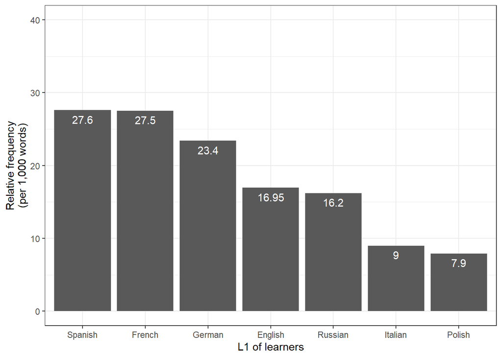

```r
err_tb %>%
  ggplot(aes(x = reorder(l1, -freq), y = freq, label = freq)) +
  geom_bar(stat = "identity") +
  geom_text(vjust=1.6, color = "white") +
  # adapt tick labels
  scale_x_discrete("L1 of learners",
                   breaks = names(table(read$l1)),
                   labels = c("en" = "English",
                              "de" = "German",
                              "es" = "Spanish",
                              "fr" = "French",
                              "it" = "Italian",
                              "pl" = "Polish",
                              "ru" = "Russian")) +
  labs(y = "Relative frequency\n(per 1,000 words)") +
  theme_bw() +
  coord_cartesian(ylim = c(0, 40)) +
  theme(legend.position = "none")
```

# Citation & Session Info

Schweinberger, Martin. 2021. *Analyzing learner language using R*. Brisbane: The University of Queensland. url: https://slcladal.github.io/llr.html.

Back to top

[Back to HOME](https://slcladal.github.io/index.html)

# References

Benoit, Kenneth, Watanabe, Kohei, Wang, Haiyan, Nulty, Paul, Obeng, Adam, Müller, Stefan and Matsuo, Akitaka (2018). quanteda: An R package for the quantitative analysis of textual data. *Journal of Open Source Software* 3(30): 774.

Benoit, Kenneth, Watanabe, Kohei, Wang, Haiyan, Lua, Jiong Wei and Kuha, Jouni (2021). Package ‘quanteda. textstats’. *Research Bulletin* 27(2): 37-54.

Flesch, Rudolph. 1948. A New Readability Yardstick. *Journal of Applied Psychology* 32(3): 221–233.

Lindquist, Hans (2009). *Corpus linguistics and the description of English*. Edinburgh: Edinburgh University Press.

Tweedie, Fiona J. and Baayen, Harald R. (1998). How Variable May a Constant Be? Measures of Lexical Richness in Perspective. *Computers and the Humanities* 32(5): 323–352.